# CBS5503 Final project

```python
import pandas as pd

file_path = '/content/DATA(1).xlsx'
data = pd.ExcelFile(file_path)

data.sheet_names
```

```
['Sheet1']
```

```python
df = data.parse('Sheet1')
df.head()
```

|  | Sentence | Code_Switching_Score | Complexity_Score | Emotional_Intensity_Score | Formality_Score | Sentimental_Score | Category | Caterogy2 |
| --- | --- | --- | --- | --- | --- | --- | --- | --- |
| 0 | ching u dim ar? | 0.30 | 0.500000 | 0.000000 | 1.3750 | -7.500000 | Creativity | 0 |
| 1 | ngor not bad ar.. u? | 0.24 | 0.000000 | 0.000000 | 0.0000 | -2.800000 | Creativity | 0 |
| 2 | good la. but ho lun hot ar today | 0.35 | 0.500000 | 2.000000 | 0.8125 | 17.250000 | Creativity | 0 |
| 3 | yes ar... cls.. u need water? | 0.20 | 0.166667 | 0.333333 | 0.0000 | 2.666667 | Creativity | 0 |
| 4 | ngo bring jor la thx | 0.40 | 0.600000 | 0.800000 | 1.2000 | 15.000000 | Creativity | 0 |

```python
import pandas as pd

df = pd.read_excel(r"C:\Users\asus\Documents\2024POLY-U\CBS5503\Final Project\DATA.xlsx")

print(df.head())
```

```
                           Sentence  Code_Switching_Score  Complexity_Score  \
0                   ching u dim ar?                  0.30          0.500000
1              ngor not bad ar.. u?                  0.24          0.000000
2  good la. but ho lun hot ar today                  0.35          0.500000
3     yes ar... cls.. u need water?                  0.20          0.166667
4              ngo bring jor la thx                  0.40          0.600000

   Emotional_Intensity_Score  Formality_Score  Sentimental_Score    Category
0                   0.000000           1.3750          -7.500000  Creativity
1                   0.000000           0.0000          -2.800000  Creativity
2                   2.000000           0.8125          17.250000  Creativity
3                   0.333333           0.0000           2.666667  Creativity
4                   0.800000           1.2000          15.000000  Creativity
```

```python
correlation_matrix = df[['Code_Switching_Score', 'Complexity_Score', 'Emotional_Intensity_Score', 'Formality_Score', 'Sentimental_Score']].corr()
print(correlation_matrix)
```

```
                           Code_Switching_Score  Complexity_Score  \
Code_Switching_Score                   1.000000          0.646479
Complexity_Score                       0.646479          1.000000
Emotional_Intensity_Score             -0.026352         -0.057920
Formality_Score                        0.263837          0.117268
Sentimental_Score                     -0.028234         -0.022826

                           Emotional_Intensity_Score  Formality_Score  \
Code_Switching_Score                       -0.026352         0.263837
Complexity_Score                           -0.057920         0.117268
Emotional_Intensity_Score                   1.000000         0.032044
Formality_Score                             0.032044         1.000000
Sentimental_Score                          -0.039247        -0.079154

                           Sentimental_Score
Code_Switching_Score               -0.028234
Complexity_Score                   -0.022826
Emotional_Intensity_Score          -0.039247
Formality_Score                    -0.079154
Sentimental_Score                   1.000000
```

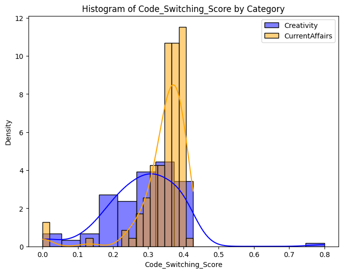

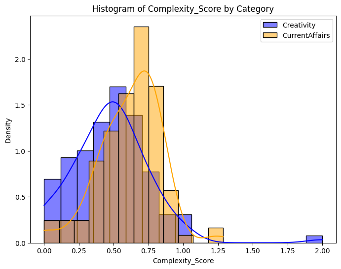

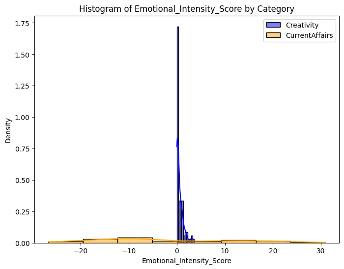

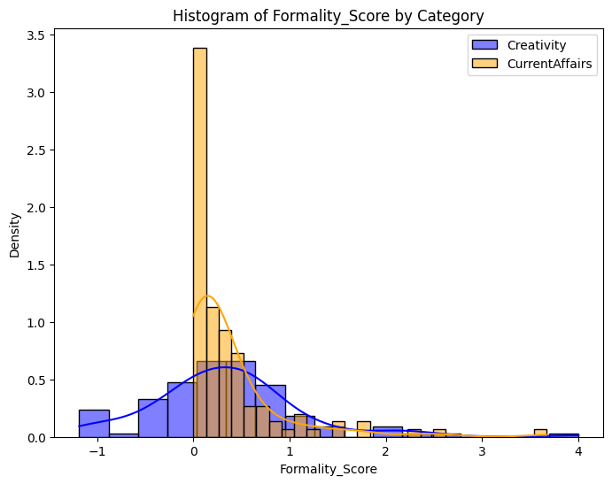

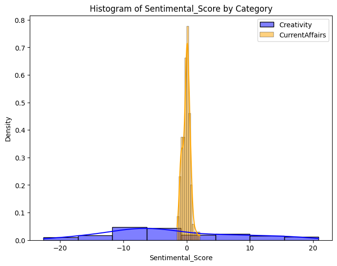

```
{'Code_Switching_Score': {'t_stat': -4.928032999288424,
  'p_value': 1.8149634977009926e-06},
 'Complexity_Score': {'t_stat': -4.162850716834733,
  'p_value': 4.6252988082245625e-05},
 'Emotional_Intensity_Score': {'t_stat': 2.578816146918488,
  'p_value': 0.011179374394612607},
 'Formality_Score': {'t_stat': -0.32587004639717787,
  'p_value': 0.7448693280144068},
 'Sentimental_Score': {'t_stat': -2.410834675550382,
  'p_value': 0.017576228539132}}
```

```python
import seaborn as sns
import matplotlib.pyplot as plt
from scipy.stats import ttest_ind

scores_columns = [
    'Code_Switching_Score',
    'Complexity_Score',
    'Emotional_Intensity_Score',
    'Formality_Score',
    'Sentimental_Score'
]
category_column = 'Category'

categories = df[category_column].unique()

if len(categories) != 2:
    raise ValueError("The t-test requires exactly two categories in the classification variable.")

group1 = df[df[category_column] == categories[0]]
group2 = df[df[category_column] == categories[1]]

t_test_results = {}
for score in scores_columns:
    t_stat, p_value = ttest_ind(group1[score], group2[score], equal_var=False)
    t_test_results[score] = {'t_stat': t_stat, 'p_value': p_value}

    plt.figure(figsize=(8, 6))
    sns.histplot(group1[score], color='blue', label=f"{categories[0]}", kde=True, stat="density")
    sns.histplot(group2[score], color='orange', label=f"{categories[1]}", kde=True, stat="density")
    plt.title(f'Histogram of {score} by {category_column}')
    plt.xlabel(score)
    plt.ylabel('Density')
    plt.legend()
    plt.show()

t_test_results
```

**t-test conclusion**

C codeswitching score: t-statistic: -4.93 p value: 1.81e-06 (significant, the mean difference between the two groups is significant)

Complexity_Score: t-statistic: -4.16 p value: 4.63e-05 (significant, the mean difference between the two groups is significant)

Emotional_Intensity_Score: t-statistic: 2.58 p value: 0.011 (significant, the mean difference between the two groups is significant)

Formality_Score: t-statistic: -0.33 p value: 0.745 (not significant, the difference between the means of the two groups is not significant)

Sentimental_Score: t-statistic: -2.41 p value: 0.018 (significant, the mean difference between the two groups is significant)

```
Regression Summary for Code_Switching_Score:
                             OLS Regression Results
================================================================================
Dep. Variable:     Code_Switching_Score   R-squared:                       0.100
Model:                              OLS   Adj. R-squared:                  0.096
Method:                   Least Squares   F-statistic:                     24.71
Date:                  Mon, 25 Nov 2024   Prob (F-statistic):           1.33e-06
Time:                          11:08:08   Log-Likelihood:                 218.43
No. Observations:                   225   AIC:                            -432.9
Df Residuals:                       223   BIC:                            -426.0
Df Model:                             1
Covariance Type:              nonrobust
==============================================================================
                 coef    std err          t      P>|t|      [0.025      0.975]
------------------------------------------------------------------------------
const          0.2850      0.009     32.467      0.000       0.268       0.302
Category_2     0.0610      0.012      4.971      0.000       0.037       0.085
==============================================================================
Omnibus:                       51.936   Durbin-Watson:                   1.787
Prob(Omnibus):                  0.000   Jarque-Bera (JB):              430.205
Skew:                          -0.580   Prob(JB):                     3.82e-94
Kurtosis:                       9.674   Cond. No.                         2.64
==============================================================================

Notes:
[1] Standard Errors assume that the covariance matrix of the errors is correctly specified.
```

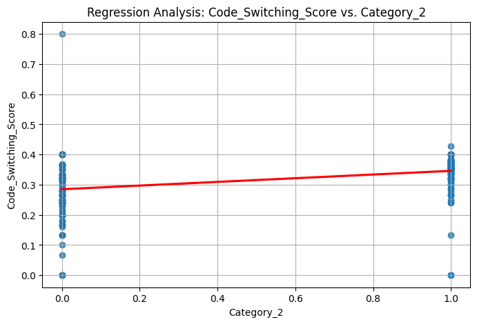

```
Regression Summary for Complexity_Score:
                            OLS Regression Results
==============================================================================
Dep. Variable:       Complexity_Score   R-squared:                       0.073
Model:                            OLS   Adj. R-squared:                  0.069
Method:                 Least Squares   F-statistic:                     17.53
Date:                Mon, 25 Nov 2024   Prob (F-statistic):           4.08e-05
Time:                        11:08:08   Log-Likelihood:                -9.7928
No. Observations:                 225   AIC:                             23.59
Df Residuals:                     223   BIC:                             30.42
Df Model:                           1
Covariance Type:            nonrobust
==============================================================================
                 coef    std err          t      P>|t|      [0.025      0.975]
------------------------------------------------------------------------------
const          0.4802      0.024     19.837      0.000       0.432       0.528
Category_2     0.1417      0.034      4.186      0.000       0.075       0.208
==============================================================================
Omnibus:                       51.484   Durbin-Watson:                   1.873
Prob(Omnibus):                  0.000   Jarque-Bera (JB):              262.588
Skew:                           0.757   Prob(JB):                     9.54e-58
Kurtosis:                       8.071   Cond. No.                         2.64
==============================================================================

Notes:
[1] Standard Errors assume that the covariance matrix of the errors is correctly specified.
```

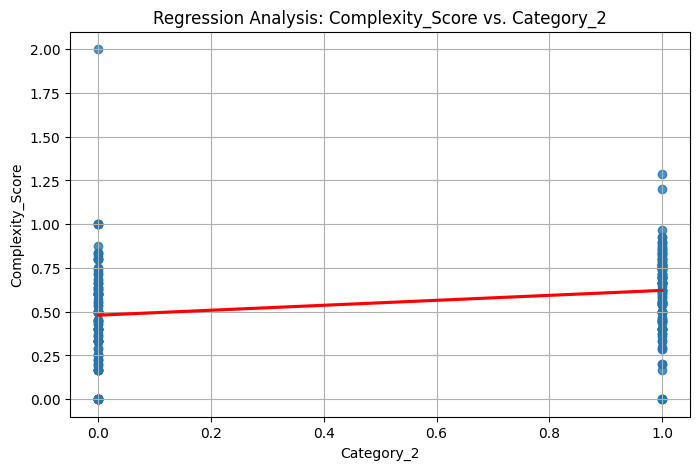

```
Regression Summary for Emotional_Intensity_Score:
                                OLS Regression Results
=====================================================================================
Dep. Variable:     Emotional_Intensity_Score   R-squared:                       0.028
Model:                                   OLS   Adj. R-squared:                  0.023
Method:                        Least Squares   F-statistic:                     6.361
Date:                       Mon, 25 Nov 2024   Prob (F-statistic):             0.0124
Time:                               11:08:09   Log-Likelihood:                -837.36
No. Observations:                        225   AIC:                             1679.
Df Residuals:                            223   BIC:                             1686.
Df Model:                                  1
Covariance Type:                   nonrobust
==============================================================================
                 coef    std err          t      P>|t|      [0.025      0.975]
------------------------------------------------------------------------------
const          0.5519      0.958      0.576      0.565      -1.336       2.439
Category_2    -3.3791      1.340     -2.522      0.012      -6.019      -0.739
==============================================================================
Omnibus:                       25.662   Durbin-Watson:                   1.786
Prob(Omnibus):                  0.000   Jarque-Bera (JB):               35.488
Skew:                           0.724   Prob(JB):                     1.97e-08
Kurtosis:                       4.299   Cond. No.                         2.64
==============================================================================

Notes:
[1] Standard Errors assume that the covariance matrix of the errors is correctly specified.
```

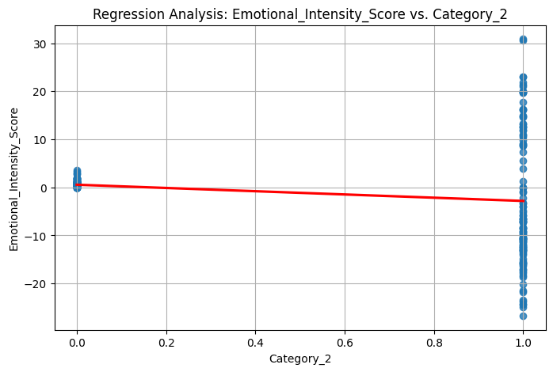

```
Regression Summary for Formality_Score:
                            OLS Regression Results
==============================================================================
Dep. Variable:        Formality_Score   R-squared:                       0.000
Model:                            OLS   Adj. R-squared:                 -0.004
Method:                 Least Squares   F-statistic:                    0.1077
Date:                Mon, 25 Nov 2024   Prob (F-statistic):              0.743
Time:                        11:08:09   Log-Likelihood:                -231.63
No. Observations:                 225   AIC:                             467.3
Df Residuals:                     223   BIC:                             474.1
Df Model:                           1
Covariance Type:            nonrobust
==============================================================================
                 coef    std err          t      P>|t|      [0.025      0.975]
------------------------------------------------------------------------------
const          0.3422      0.065      5.274      0.000       0.214       0.470
Category_2     0.0298      0.091      0.328      0.743      -0.149       0.209
==============================================================================
Omnibus:                      102.751   Durbin-Watson:                   1.852
Prob(Omnibus):                  0.000   Jarque-Bera (JB):              517.849
Skew:                           1.762   Prob(JB):                    3.55e-113
Kurtosis:                       9.543   Cond. No.                         2.64
==============================================================================

Notes:
[1] Standard Errors assume that the covariance matrix of the errors is correctly specified.
```

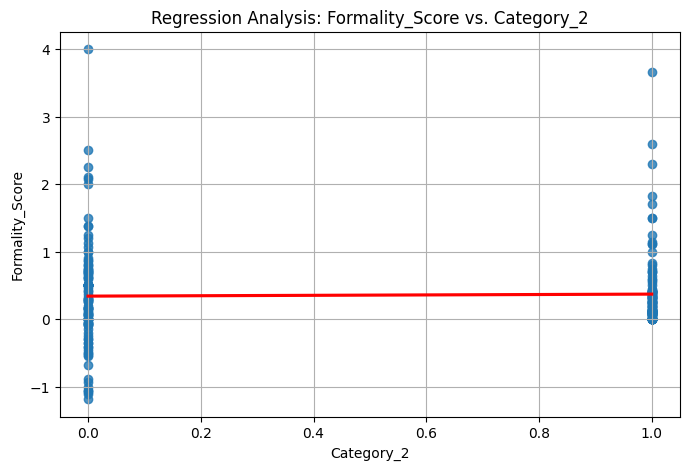

```
Regression Summary for Sentimental_Score:
                            OLS Regression Results
==============================================================================
Dep. Variable:      Sentimental_Score   R-squared:                       0.027
Model:                            OLS   Adj. R-squared:                  0.022
Method:                 Least Squares   F-statistic:                     6.075
Date:                Mon, 25 Nov 2024   Prob (F-statistic):             0.0145
Time:                        11:08:09   Log-Likelihood:                -755.76
No. Observations:                 225   AIC:                             1516.
Df Residuals:                     223   BIC:                             1522.
Df Model:                           1
Covariance Type:            nonrobust
==============================================================================
                 coef    std err          t      P>|t|      [0.025      0.975]
------------------------------------------------------------------------------
const         -2.3371      0.666     -3.507      0.001      -3.650      -1.024
Category_2     2.2978      0.932      2.465      0.014       0.461       4.135
==============================================================================
Omnibus:                       25.742   Durbin-Watson:                   2.001
Prob(Omnibus):                  0.000   Jarque-Bera (JB):               46.791
Skew:                           0.610   Prob(JB):                     6.91e-11
Kurtosis:                       4.872   Cond. No.                         2.64
==============================================================================

Notes:
[1] Standard Errors assume that the covariance matrix of the errors is correctly specified.
```

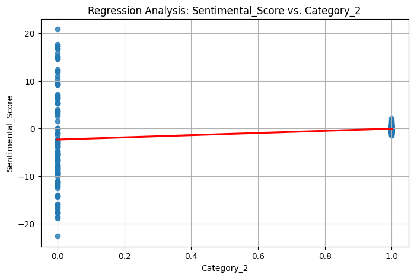

```python
import statsmodels.api as sm
import matplotlib.pyplot as plt
import seaborn as sns

score_columns = [
    'Code_Switching_Score',
    'Complexity_Score',
    'Emotional_Intensity_Score',
    'Formality_Score',
    'Sentimental_Score'
]

regression_results = {}

for score in score_columns:
    X = df[['Category_2']]
    y = df[score]

    X = sm.add_constant(X)

    model = sm.OLS(y, X).fit()
    regression_results[score] = model

    print(f"Regression Summary for {score}:")
    print(model.summary())

    plt.figure(figsize=(8, 5))
    sns.regplot(x='Category_2', y=score, data=df, ci=None, line_kws={'color': 'red'})
    plt.title(f"Regression Analysis: {score} vs. Category_2")
    plt.xlabel('Category_2')
    plt.ylabel(score)
    plt.grid(True)
    plt.show()
```

Code Interpretation score_columns: The list contains five dependent variables that need to be regressed.

Regression Analysis: Use statsmodels's OLS (Ordinary Least Squares) to fit the model, with Category_2 as the independent variable and the five scores as dependent variables.

Regression Visualization: Use seaborn.regplot to draw a scatter plot and regression line for each dependent variable and Category_2.

Regression Results: In the code, model.summary() prints the statistical results of each regression model, including coefficients, standard errors, t values, p values, and R-squared.

**Regression analysis conclusion:** Except for the formality_score score, which is not significantly different (p=0.743), the other scores are significantly different. The emotional_intensity_score score generally shows creativity>current affairs, and the other three scores are all current affairs>cretivity.

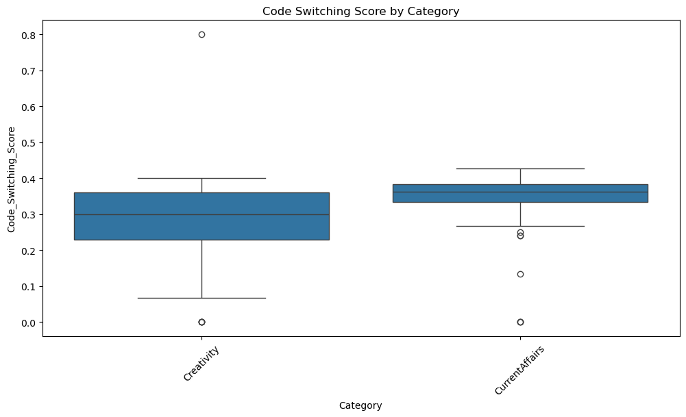

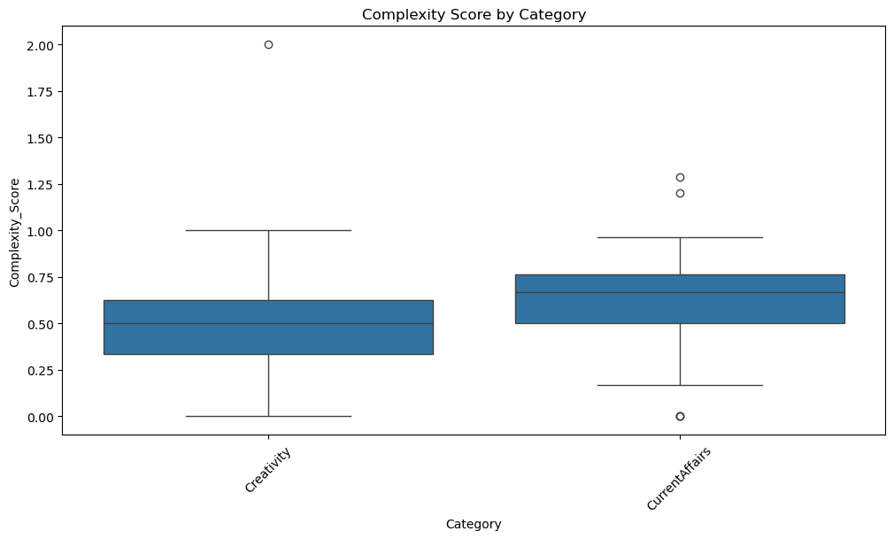

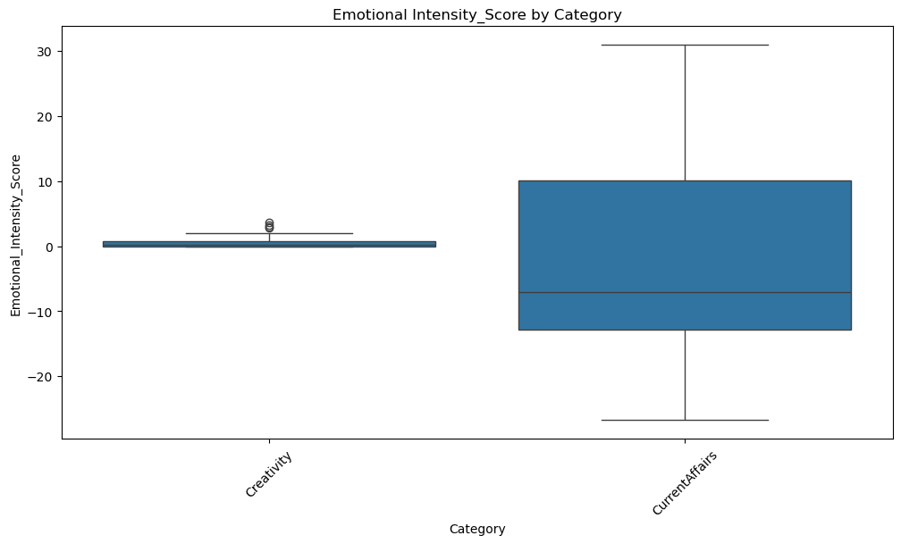

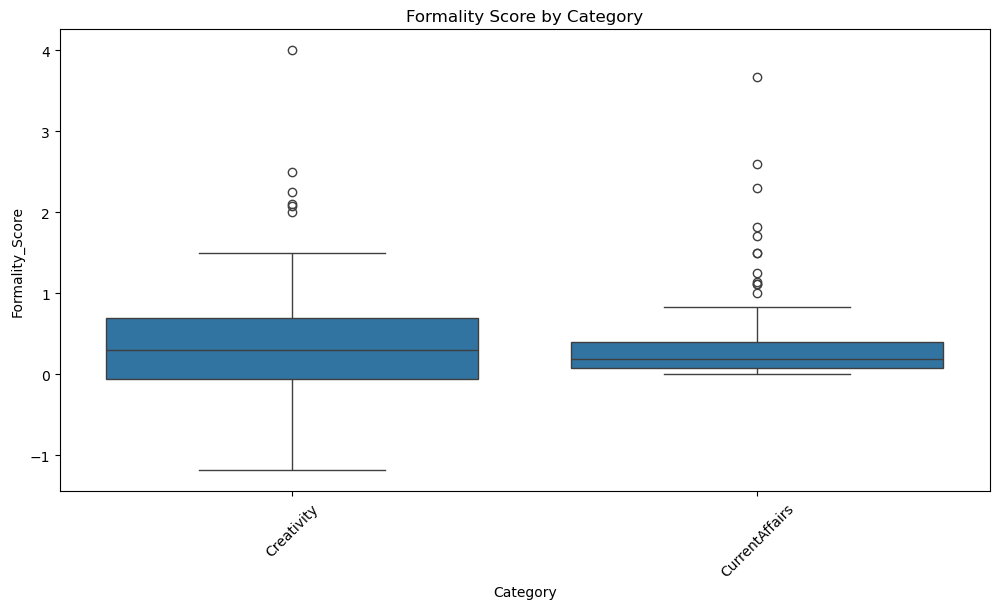

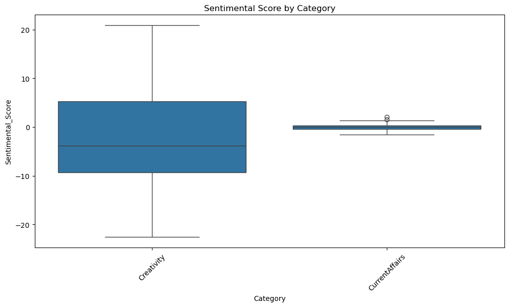

```python
import seaborn as sns
import matplotlib.pyplot as plt

plt.figure(figsize=(12, 6))
sns.boxplot(data=df, x='Category', y='Code_Switching_Score')
plt.title('Code Switching Score by Category')
plt.xticks(rotation=45)
plt.show()

plt.figure(figsize=(12, 6))
sns.boxplot(data=df, x='Category', y='Complexity_Score')
plt.title('Complexity Score by Category')
plt.xticks(rotation=45)
plt.show()

plt.figure(figsize=(12, 6))
sns.boxplot(data=df, x='Category', y='Emotional_Intensity_Score')
plt.title('Emotional Intensity_Score by Category')
plt.xticks(rotation=45)
plt.show()

plt.figure(figsize=(12, 6))
sns.boxplot(data=df, x='Category', y='Formality_Score')
plt.title('Formality Score by Category')
plt.xticks(rotation=45)
plt.show()

plt.figure(figsize=(12, 6))
sns.boxplot(data=df, x='Category', y='Sentimental_Score')
plt.title('Sentimental Score by Category')
plt.xticks(rotation=45)
plt.show()
```

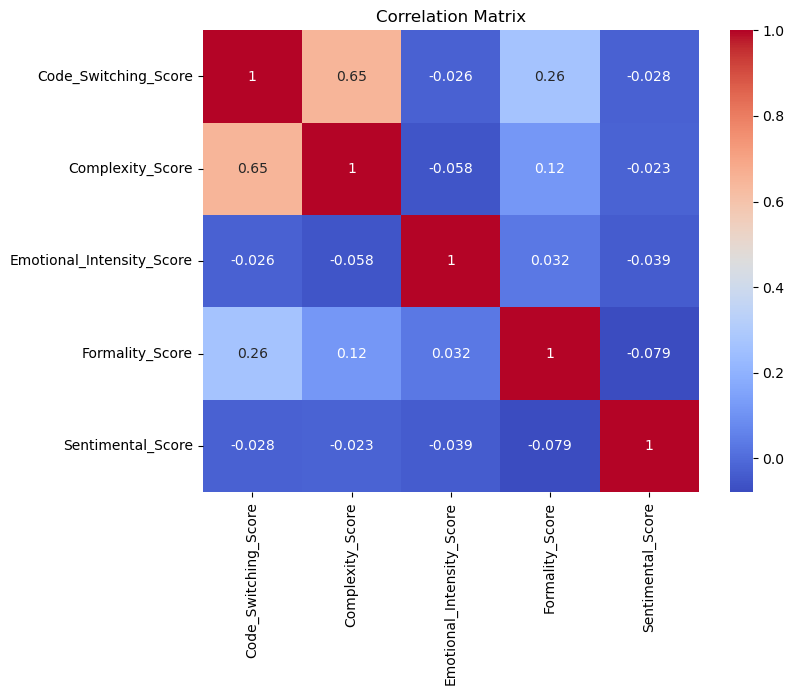

```python
import matplotlib.pyplot as plt

plt.figure(figsize=(8, 6))
sns.heatmap(correlation_matrix, annot=True, cmap='coolwarm')
plt.title('Correlation Matrix')
plt.show()
```

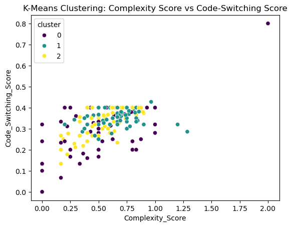

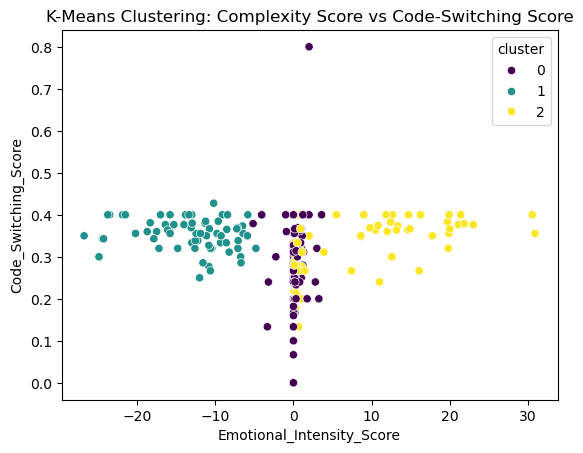

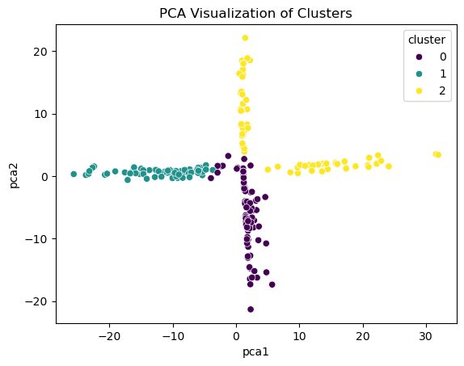

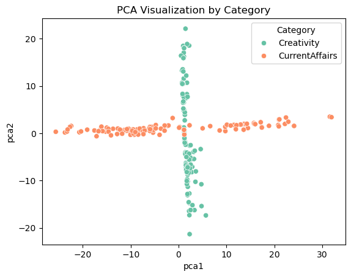

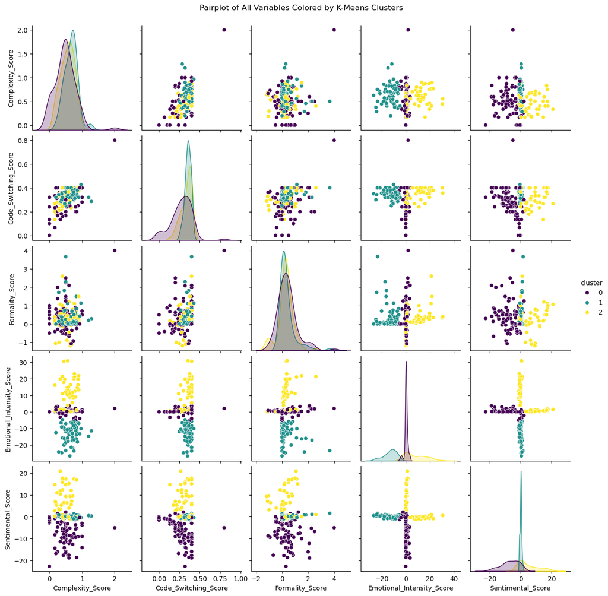

```python
from sklearn.cluster import KMeans
from sklearn.decomposition import PCA
import seaborn as sns
import matplotlib.pyplot as plt

X = df[['Complexity_Score', 'Code_Switching_Score', 'Formality_Score', 'Emotional_Intensity_Score', 'Sentimental_Score']]

kmeans = KMeans(n_clusters=3, random_state=42)
df['cluster'] = kmeans.fit_predict(X)

sns.scatterplot(
    x='Complexity_Score',
    y='Code_Switching_Score',
    hue='cluster',
    data=df,
    palette='viridis'
)
plt.title('K-Means Clustering: Complexity Score vs Code-Switching Score')
plt.show()

sns.scatterplot(
    x='Emotional_Intensity_Score',
    y='Code_Switching_Score',
    hue='cluster',
    data=df,
    palette='viridis'
)
plt.title('K-Means Clustering: Complexity Score vs Code-Switching Score')
plt.show()


pca = PCA(n_components=2)
X_pca = pca.fit_transform(X)
df['pca1'], df['pca2'] = X_pca[:, 0], X_pca[:, 1]

sns.scatterplot(
    x='pca1',
    y='pca2',
    hue='cluster',
    data=df,
    palette='viridis'
)
plt.title('PCA Visualization of Clusters')
plt.show()

sns.scatterplot(
    x='pca1',
    y='pca2',
    hue='Category',
    data=df,
    palette='Set2'
)
plt.title('PCA Visualization by Category')
plt.show()

sns.pairplot(
    df,
    vars=['Complexity_Score', 'Code_Switching_Score', 'Formality_Score', 'Emotional_Intensity_Score', 'Sentimental_Score'],
    hue='cluster',
    palette='viridis',
    diag_kind='kde'
)
plt.suptitle('Pairplot of All Variables Colored by K-Means Clusters', y=1.02)
plt.show()
```